# Titanic Machine Learning Survival

In this challenge, we ask you to complete the analysis of what sorts of people were likely to survive. In particular, we ask you to apply the tools of machine learning to predict which passengers survived the tragedy.

### Goal

It is your job to predict if a passenger survived the sinking of the Titanic or not. For each PassengerId in the test set, you must predict a 0 or 1 value for the Survived variable.

### Metric

Your score is the percentage of passengers you correctly predict. This is known simply as "accuracy”.

The training set should be used to build your machine learning models. For the training set, we provide the outcome (also known as the “ground truth”) for each passenger. Your model will be based on “features” like passengers’ gender and class. You can also use feature engineering to create new features.

The test set should be used to see how well your model performs on unseen data. For the test set, we do not provide the ground truth for each passenger. It is your job to predict these outcomes. For each passenger in the test set, use the model you trained to predict whether or not they survived the sinking of the Titanic.

### Base Model All Died - 0.62679

### Model #2 - All Females Survived Model - 0.76

### Model #3 - Class 1 and Class 2 Survived & rest died - 0.58

```python
# Import the Dataset
import pandas as pd
import numpy as np
import matplotlib.pyplot as plt
import seaborn as sns
```

```python
df_train = pd.read_csv("~/Downloads//Titanic Data set/train.csv")
df_test = pd.read_csv("~/Downloads//Titanic Data set/test.csv")
```

```python
df_train.head()
```

|  | PassengerId | Survived | Pclass | Name | Sex | Age | SibSp | Parch | Ticket | Fare | Cabin | Embarked |
| --- | --- | --- | --- | --- | --- | --- | --- | --- | --- | --- | --- | --- |
| 0 | 1 | 0 | 3 | Braund, Mr. Owen Harris | male | 22.0 | 1 | 0 | A/5 21171 | 7.2500 | NaN | S |
| 1 | 2 | 1 | 1 | Cumings, Mrs. John Bradley (Florence Briggs Th... | female | 38.0 | 1 | 0 | PC 17599 | 71.2833 | C85 | C |
| 2 | 3 | 1 | 3 | Heikkinen, Miss. Laina | female | 26.0 | 0 | 0 | STON/O2. 3101282 | 7.9250 | NaN | S |
| 3 | 4 | 1 | 1 | Futrelle, Mrs. Jacques Heath (Lily May Peel) | female | 35.0 | 1 | 0 | 113803 | 53.1000 | C123 | S |
| 4 | 5 | 0 | 3 | Allen, Mr. William Henry | male | 35.0 | 0 | 0 | 373450 | 8.0500 | NaN | S |

##### Here we as we see in the Train Data - Survived is the column which we want to predict. The rest are Predictor Variables.

##### Note - We will be dropping Passenger ID, Name, Ticket and Cabin because these columns are creating noise in the dataset

```python
df_test.head()
```

|  | PassengerId | Pclass | Name | Sex | Age | SibSp | Parch | Ticket | Fare | Cabin | Embarked |
| --- | --- | --- | --- | --- | --- | --- | --- | --- | --- | --- | --- |
| 0 | 892 | 3 | Kelly, Mr. James | male | 34.5 | 0 | 0 | 330911 | 7.8292 | NaN | Q |
| 1 | 893 | 3 | Wilkes, Mrs. James (Ellen Needs) | female | 47.0 | 1 | 0 | 363272 | 7.0000 | NaN | S |
| 2 | 894 | 2 | Myles, Mr. Thomas Francis | male | 62.0 | 0 | 0 | 240276 | 9.6875 | NaN | Q |
| 3 | 895 | 3 | Wirz, Mr. Albert | male | 27.0 | 0 | 0 | 315154 | 8.6625 | NaN | S |
| 4 | 896 | 3 | Hirvonen, Mrs. Alexander (Helga E Lindqvist) | female | 22.0 | 1 | 1 | 3101298 | 12.2875 | NaN | S |

```python
df_train.shape
```

```
(891, 12)
```

```python
df_test.shape
```

```
(418, 11)
```

```python
# Find the Missing Values from Train Set
df_train.isnull().sum()
```

```
PassengerId      0
Survived         0
Pclass           0
Name             0
Sex              0
Age            177
SibSp            0
Parch            0
Ticket           0
Fare             0
Cabin          687
Embarked         2
dtype: int64
```

### Missing Values Columns are AGE, Cabin, Embarked

```python
# Description of the Columns
df_train.describe()
```

|  | PassengerId | Survived | Pclass | Age | SibSp | Parch | Fare |
| --- | --- | --- | --- | --- | --- | --- | --- |
| count | 891.000000 | 891.000000 | 891.000000 | 714.000000 | 891.000000 | 891.000000 | 891.000000 |
| mean | 446.000000 | 0.383838 | 2.308642 | 29.699118 | 0.523008 | 0.381594 | 32.204208 |
| std | 257.353842 | 0.486592 | 0.836071 | 14.526497 | 1.102743 | 0.806057 | 49.693429 |
| min | 1.000000 | 0.000000 | 1.000000 | 0.420000 | 0.000000 | 0.000000 | 0.000000 |
| 25% | 223.500000 | 0.000000 | 2.000000 | 20.125000 | 0.000000 | 0.000000 | 7.910400 |
| 50% | 446.000000 | 0.000000 | 3.000000 | 28.000000 | 0.000000 | 0.000000 | 14.454200 |
| 75% | 668.500000 | 1.000000 | 3.000000 | 38.000000 | 1.000000 | 0.000000 | 31.000000 |
| max | 891.000000 | 1.000000 | 3.000000 | 80.000000 | 8.000000 | 6.000000 | 512.329200 |

## Exploratory Data Analysis

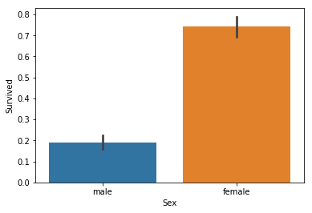

```python
# Create a Plot between Gender and Survived.
sns.barplot(x = "Sex", y ="Survived", data= df_train)
```

#### Conclusion: Most of the Females Survived in comparison to Males

#### Kaggle Submission - 0.76555

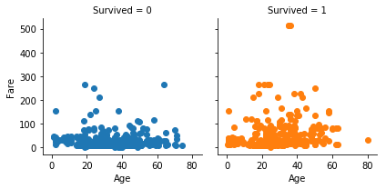

```python
# FACET GRID PLOT - Fare Vs Age and Faceting - Survived Col
g = sns.FacetGrid(df_train, col="Survived", hue="Survived") # plane of Facets
g.map(plt.scatter, "Age", "Fare") # Plots
```

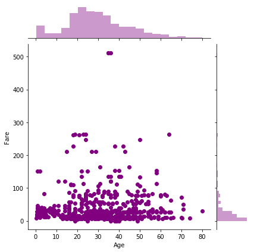

```python
sns.jointplot("Age", "Fare", df_train, color="purple")
```

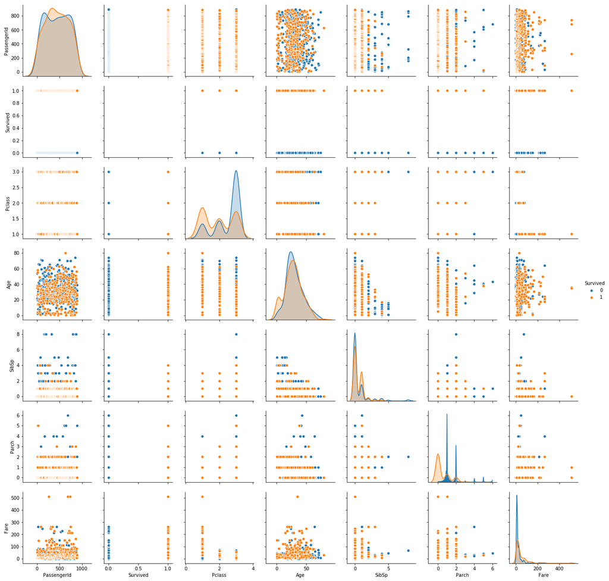

```python
sns.pairplot(df_train, hue="Survived")
```

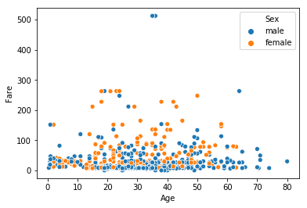

```python
sns.scatterplot("Age","Fare", data=df_train, hue="Sex")
```

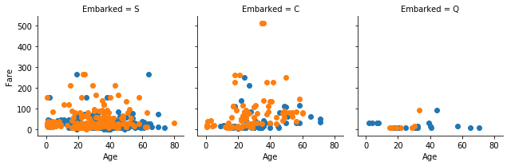

```python
# Lets Find out the Survival Basis the Port of Embarkation
s = sns.FacetGrid(df_train, col="Embarked", hue="Survived")
s.map(plt.scatter, "Age", "Fare")
```

#### Boarding Ports in the Order of Max to Min

1. SouthHampton
2. Cherbourg
3. Queenstown

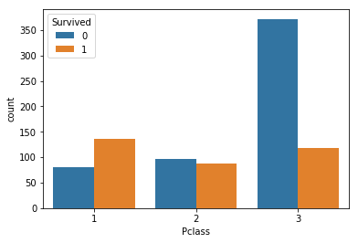

```python
# Lets Find the PCLASS vs Survived
sns.countplot(x = "Pclass", data=df_train, hue="Survived")

# Mostly Class 03 Passengers Died and Class 01 has the lowest Death Rate in comp to Other Class
```

##### If Class 03 - No Survival else Female Survived

##### Lets find out the survived people basis Passenger Class. My Hunch is Class 1 will see a better survival rate

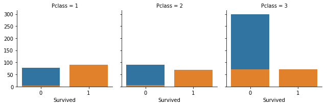

```python
# Finding the Survival Gender Wise and Faceting using Pclass
h = sns.FacetGrid(df_train, col="Pclass", hue="Sex")
h.map(sns.countplot, "Survived")
```

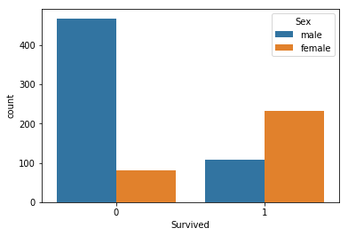

```python
sns.countplot(x = "Survived", hue = "Sex", data=df_train)
```

### Imputing Missing Values

```python
# Finding the Mean of Age Variable
print(df_train["Age"].mean())
print(df_train["Age"].median())
```

```
29.69911764705882
28.0
```

```python
# Imputed Median in AGE
df_train["Age"]=df_train["Age"].fillna(28) # Taken 28 as Median Value is used to impute
```

```python
# Imputed Median in AGE _ Test
df_test["Age"]=df_test["Age"].fillna(27) # Median Value of Age Variable in Test Set
```

```python
df_test.isnull().sum()
```

```
PassengerId      0
Pclass           0
Name             0
Sex              0
Age              0
SibSp            0
Parch            0
Ticket           0
Fare             1
Cabin          327
Embarked         0
dtype: int64
```

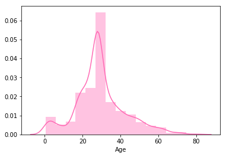

```python
# Histogram of Age
sns.distplot(df_train["Age"], color="hotpink", bins =15)
```

```python
# Imputed Mode in Embarked
df_train["Embarked"].mode() # SouthHampton appears the Most
```

```
0    S
dtype: object
```

```python
df_train["Embarked"] = df_train["Embarked"].fillna("S") # Filing the Missing Value using Mode()
```

```python
# Fare in test
df_test["Fare"].median()
df_test["Fare"]=df_test["Fare"].fillna(14.452) # Median value for Fare
```

```python
# Missing Values of Cabin - Train Data
df_train["Cabin"] = df_train["Cabin"].fillna("N") # Created a Dummy Variable
```

```python
# Missing Values of Cabin - Test Set
df_test["Cabin"] = df_test["Cabin"].fillna("N") # Created a Dummy Variable
```

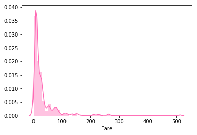

```python
# Histogram of Fare
sns.distplot(df_train["Fare"], color="hotpink") # Highly Skewed:: Fare is always skewed in Nature
```

```python
df_train.head()
```

|  | PassengerId | Survived | Pclass | Name | Sex | Age | SibSp | Parch | Ticket | Fare | Cabin | Embarked |
| --- | --- | --- | --- | --- | --- | --- | --- | --- | --- | --- | --- | --- |
| 0 | 1 | 0 | 3 | Braund, Mr. Owen Harris | male | 22.0 | 1 | 0 | A/5 21171 | 7.2500 | N | S |
| 1 | 2 | 1 | 1 | Cumings, Mrs. John Bradley (Florence Briggs Th... | female | 38.0 | 1 | 0 | PC 17599 | 71.2833 | C85 | C |
| 2 | 3 | 1 | 3 | Heikkinen, Miss. Laina | female | 26.0 | 0 | 0 | STON/O2. 3101282 | 7.9250 | N | S |
| 3 | 4 | 1 | 1 | Futrelle, Mrs. Jacques Heath (Lily May Peel) | female | 35.0 | 1 | 0 | 113803 | 53.1000 | C123 | S |
| 4 | 5 | 0 | 3 | Allen, Mr. William Henry | male | 35.0 | 0 | 0 | 373450 | 8.0500 | N | S |

```python
# Fare and Class
df_train[df_train["Pclass"]==1]["Fare"].median()
```

```
60.287499999999994
```

### Feature Engineering

Since we know that Sibsp(Siblings and Spouse) and Parch(Parents & Children) are the variables that represents whole family so we need to add 01 if both are 0. It means that the person is a lone traveller and is travelling alone.

We will create a new variable called Family

```python
# Combine SIBSP and PARCH and Add 1
df_train["Family"] =df_train["SibSp"]+df_train["Parch"]+1
```

```python
# Combine SIBSP and PARCH and Add 1 - Test
df_test["Family"] =df_test["SibSp"]+df_test["Parch"]+1
```

```python
df_test.head()
```

|  | PassengerId | Pclass | Name | Sex | Age | SibSp | Parch | Ticket | Fare | Cabin | Embarked | Family |
| --- | --- | --- | --- | --- | --- | --- | --- | --- | --- | --- | --- | --- |
| 0 | 892 | 3 | Kelly, Mr. James | male | 34.5 | 0 | 0 | 330911 | 7.8292 | N | Q | 1 |
| 1 | 893 | 3 | Wilkes, Mrs. James (Ellen Needs) | female | 47.0 | 1 | 0 | 363272 | 7.0000 | N | S | 2 |
| 2 | 894 | 2 | Myles, Mr. Thomas Francis | male | 62.0 | 0 | 0 | 240276 | 9.6875 | N | Q | 1 |
| 3 | 895 | 3 | Wirz, Mr. Albert | male | 27.0 | 0 | 0 | 315154 | 8.6625 | N | S | 1 |
| 4 | 896 | 3 | Hirvonen, Mrs. Alexander (Helga E Lindqvist) | female | 22.0 | 1 | 1 | 3101298 | 12.2875 | N | S | 3 |

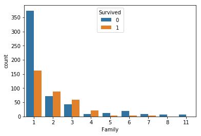

```python
sns.countplot(x = "Family", hue="Survived", data=df_train)
```

```python
newdf = df_train.copy
```

```python
df_train.head()
```

|  | PassengerId | Survived | Pclass | Name | Sex | Age | SibSp | Parch | Ticket | Fare | Cabin | Embarked | Family |
| --- | --- | --- | --- | --- | --- | --- | --- | --- | --- | --- | --- | --- | --- |
| 0 | 1 | 0 | 3 | Braund, Mr. Owen Harris | male | 22.0 | 1 | 0 | A/5 21171 | 7.2500 | N | S | 2 |
| 1 | 2 | 1 | 1 | Cumings, Mrs. John Bradley (Florence Briggs Th... | female | 38.0 | 1 | 0 | PC 17599 | 71.2833 | C85 | C | 2 |
| 2 | 3 | 1 | 3 | Heikkinen, Miss. Laina | female | 26.0 | 0 | 0 | STON/O2. 3101282 | 7.9250 | N | S | 1 |
| 3 | 4 | 1 | 1 | Futrelle, Mrs. Jacques Heath (Lily May Peel) | female | 35.0 | 1 | 0 | 113803 | 53.1000 | C123 | S | 2 |
| 4 | 5 | 0 | 3 | Allen, Mr. William Henry | male | 35.0 | 0 | 0 | 373450 | 8.0500 | N | S | 1 |

### Feature Engineering - Name Variable.

Extracting Titles from the Name Variable. We will extract all the titles and will keep only Mr, Mrs, Ms, Miss and Master. All other titles will be converted into Others

```python
# Extracting the Titles from the TEST
names_train = df_train.Name.apply(lambda x: x.split(", ")[-1])
# Applying Split - Cleansing the Titles
titles_train = names_train.apply(lambda x: x.split(". ")[0])
# Finding the Unique Title Values
titles_train.unique()
```

```
array(['Mr', 'Mrs', 'Miss', 'Master', 'Don', 'Rev', 'Dr', 'Mme', 'Ms',
       'Major', 'Lady', 'Sir', 'Mlle', 'Col', 'Capt', 'the Countess',
       'Jonkheer'], dtype=object)
```

```python
# Creating an Array of Titles which will be converted into Others
titles_ignore = ['Don', 'Rev', 'Dr', 'Mme',"Dona"
       'Major', 'Lady', 'Sir', 'Mlle', 'Col', 'Capt', 'the Countess',
       'Jonkheer']
```

```python
df_train["Titles"] = titles_train
df_train.Titles.unique()
```

```
array(['Mr', 'Mrs', 'Miss', 'Master', 'Don', 'Rev', 'Dr', 'Mme', 'Ms',
       'Major', 'Lady', 'Sir', 'Mlle', 'Col', 'Capt', 'the Countess',
       'Jonkheer'], dtype=object)
```

```python
# Replacing the titles with Others
df_train.Titles = titles_train.replace(to_replace=titles_ignore, value="Others")
df_train.Titles.unique()
```

```
array(['Mr', 'Mrs', 'Miss', 'Master', 'Others', 'Ms', 'Major'],
      dtype=object)
```

```python
df_train.Titles = df_train.Titles.replace(to_replace="Major", value = "Others")
df_train.Titles.unique()
```

```
array(['Mr', 'Mrs', 'Miss', 'Master', 'Others', 'Ms'], dtype=object)
```

```python
# Extracting the Titles from the TEST
names = df_test.Name.apply(lambda x: x.split(", ")[-1])
```

```python
names
```

```
0                                           Mr. James
1                            Mrs. James (Ellen Needs)
2                                  Mr. Thomas Francis
3                                          Mr. Albert
4                  Mrs. Alexander (Helga E Lindqvist)
5                                    Mr. Johan Cervin
6                                          Miss. Kate
7                                  Mr. Albert Francis
8                    Mrs. Joseph (Sophie Halaut Easu)
9                                     Mr. John Samuel
10                                           Mr. Ylio
11                                Mr. Charles Cresson
12              Mrs. John Pillsbury (Nelle Stevenson)
13                                       Mr. Benjamin
14     Mrs. Herbert Fuller (Carrie Constance Toogood)
```

[output cut: 47 more lines]

```python
# Applying Split - Cleansing the Titles
titles = names.apply(lambda x: x.split(". ")[0])
```

```python
# Finding the Unique Title Values
titles.unique()
```

```
array(['Mr', 'Mrs', 'Miss', 'Master', 'Ms', 'Col', 'Rev', 'Dr', 'Dona'],
      dtype=object)
```

```python
# Creating an Array of Titles which will be converted into Others
titles_ignore = ['Don', 'Rev', 'Dr', 'Mme',"Dona"
       'Major', 'Lady', 'Sir', 'Mlle', 'Col', 'Capt', 'the Countess',
       'Jonkheer']
```

```python
df_test["Titles"] = titles
```

```python
df_test.Titles.unique()
```

```
array(['Mr', 'Mrs', 'Miss', 'Master', 'Ms', 'Col', 'Rev', 'Dr', 'Dona'],
      dtype=object)
```

```python
# Replacing the titles with Others
df_test.Titles = titles.replace(to_replace=titles_ignore, value="Others")
df_test.Titles.unique()
```

```
array(['Mr', 'Mrs', 'Miss', 'Master', 'Ms', 'Others', 'Dona'],
      dtype=object)
```

```python
df_test.Titles = df_test.Titles.replace(to_replace="Dona", value = "Others")
df_test.Titles.unique()
```

```
array(['Mr', 'Mrs', 'Miss', 'Master', 'Ms', 'Others'], dtype=object)
```

```python
print(df_train.columns)
print(df_test.columns)
```

```
Index(['PassengerId', 'Survived', 'Pclass', 'Name', 'Sex', 'Age', 'SibSp',
       'Parch', 'Ticket', 'Fare', 'Cabin', 'Embarked', 'Family', 'Titles'],
      dtype='object')
Index(['PassengerId', 'Pclass', 'Name', 'Sex', 'Age', 'SibSp', 'Parch',
       'Ticket', 'Fare', 'Cabin', 'Embarked', 'Family', 'Titles'],
      dtype='object')
```

```python
# Dropping the Unnecessary Columns
df_train = df_train.drop("PassengerId", axis = 1)
df_train = df_train.drop("Name", axis = 1)
df_train = df_train.drop("Cabin", axis=1)
df_test = df_test.drop("Cabin", axis =1)
df_train = df_train.drop("Ticket", axis = 1)
df_test = df_test.drop("Ticket", axis =1)
df_test = df_test.drop("Name", axis = 1)
```

```python
# Creating Dummy Variables for the Cat Variables (Object Data)
newtrain = pd.get_dummies(df_train)
newtest = pd.get_dummies(df_test)
```

```python
print(newtrain.columns)
print(newtest.columns)
```

```
Index(['Survived', 'Pclass', 'Age', 'SibSp', 'Parch', 'Fare', 'Family',
       'Sex_female', 'Sex_male', 'Embarked_C', 'Embarked_Q', 'Embarked_S',
       'Titles_Master', 'Titles_Miss', 'Titles_Mr', 'Titles_Mrs', 'Titles_Ms',
       'Titles_Others'],
      dtype='object')
Index(['PassengerId', 'Pclass', 'Age', 'SibSp', 'Parch', 'Fare', 'Family',
       'Sex_female', 'Sex_male', 'Embarked_C', 'Embarked_Q', 'Embarked_S',
       'Titles_Master', 'Titles_Miss', 'Titles_Mr', 'Titles_Mrs', 'Titles_Ms',
       'Titles_Others'],
      dtype='object')
```

### Notice that Train Dataset has Survived Column and Test Data doesnt have. This is what exactly we are supposed to Predict.

```python
# Dropping the Survived Col
x = newtrain.drop("Survived", axis=1)
y = newtrain["Survived"]
```

```python
from sklearn.ensemble import RandomForestClassifier, BaggingClassifier, AdaBoostClassifier, GradientBoostingClassifier
from sklearn.tree import DecisionTreeClassifier
from sklearn.cross_validation import train_test_split
from sklearn.metrics import accuracy_score
from xgboost import XGBClassifier
import xgboost as xgb
from sklearn.model_selection import GridSearchCV
```

```python
x_train,x_test,y_train,y_test = train_test_split(x, y, test_size = .30, random_state = 123)
```

```python
from sklearn.linear_model import LogisticRegression
lg = LogisticRegression()
tree = DecisionTreeClassifier()
rf = RandomForestClassifier()
ada = AdaBoostClassifier()
xgbo = XGBClassifier()
gbm = GradientBoostingClassifier()
```

```python
# Logistic Regression
model_lg = lg.fit(x_train, y_train)
pred_lg = lg.predict(x_test)
accuracy_score(y_test, pred_lg)
```

```
0.8395522388059702
```

```python
# Decision Tree Model
model_tree = tree.fit(x_train, y_train)
pred_tree = tree.predict(x_test)
accuracy_score(y_test, pred_tree)
```

```
0.7947761194029851
```

```python
# Random Forest
model_rf = rf.fit(x_train, y_train)
pred_rf = rf.predict(x_test)
accuracy_score(y_test, pred_rf)
```

```
0.7835820895522388
```

```python
# ADABOOST MODEL
model_ada = ada.fit(x_train, y_train)
pred_ada = ada.predict(x_test)
accuracy_score(y_test, pred_ada)
```

```
0.8395522388059702
```

```python
# GBM MODEL
model_gbm = gbm.fit(x_train, y_train)
pred_gbm = gbm.predict(x_test)
accuracy_score(y_test, pred_gbm)
```

```
0.8432835820895522
```

```python
# XGBOOST
model_xgbo = xgbo.fit(x_train, y_train)
pred_xgbo = xgbo.predict(x_test)
accuracy_score(y_test, pred_xgbo)
```

```
0.8470149253731343
```

```python
from sklearn.ensemble import VotingClassifier
v = VotingClassifier(estimators=[("Logreg", lg),("Trees", tree),("RF", rf), ("ADA", ada),("XG", xgbo), ("GBM", gbm)])
```

```python
newmodel_vc = v.fit(x_train, y_train)
newmodel_pred = v.predict(x_test)
accuracy_score(y_test, newmodel_pred)
```

```
0.8470149253731343
```

```python
newtest = newtest.drop("PassengerId", axis =1)
```

```python
# Predicting on test Data
m = v.fit(x,y)
pred = v.predict(newtest)
```

```python
newtest["Survived"] = pred
```

```python
# Creating a Dataframe of Passenger ID and Prediction Values
PassengerID = df_test["PassengerId"].values.tolist()
Prediction = newtest["Survived"].values.tolist()
d = {"PassengerId":PassengerID, "Survived":Prediction}
```

```python
solution = pd.DataFrame(data=d)
solution.head()
```

|  | PassengerId | Survived |
| --- | --- | --- |
| 0 | 892 | 0 |
| 1 | 893 | 0 |
| 2 | 894 | 0 |
| 3 | 895 | 0 |
| 4 | 896 | 1 |

```python
solution.to_csv("~/Downloads/votting.csv", index=False)
```

```python
# Remove Survived col
newtest = newtest.drop("Survived", axis =1)
```

```python
# # Predicting on test Data - Random Forest Model

m = rf.fit(x,y)
```

```python
pred_new = rf.predict(newtest)
```

```python
# Creating a Dataframe of Passenger ID and Prediction Values
PassengerID = df_test["PassengerId"].values.tolist()
Prediction = pred_new
d = {"PassengerId":PassengerID, "Survived":pred_new}
```

```python
solution = pd.DataFrame(data=d)
solution.head()
```

|  | PassengerId | Survived |
| --- | --- | --- |
| 0 | 892 | 0 |
| 1 | 893 | 0 |
| 2 | 894 | 0 |
| 3 | 895 | 1 |
| 4 | 896 | 1 |

```python
solution.to_csv("~/Downloads/RF.csv", index=False)
```

```python
# Bagging
from sklearn.ensemble import BaggingClassifier
```

```python
bagg = BaggingClassifier()
```

```python
g = bagg.fit(x,y)
```

```python
h = bagg.predict(newtest)
```

```python
# Creating a Dataframe of Passenger ID and Prediction Values
PassengerID = df_test["PassengerId"].values.tolist()
Prediction = h
d = {"PassengerId":PassengerID, "Survived":h}
solution = pd.DataFrame(data=d)
solution.to_csv("~/Downloads/BaggingModel.csv", index=False)
```

```python
# Finding the Parameters of Adaboost
boostparam={
    "base_estimator":[rf],
    "n_estimators":[50,75,100],
    "learning_rate":[1,2,3,4,5],
    "algorithm":["SAMME", "SAMME.R"],
    "random_state" : [123]
}
```

[output not shown]

```python
grid_boost = GridSearchCV(ada,boostparam, cv = 5)
```

```python
ada = AdaBoostClassifier(algorithm= 'SAMME',
 learning_rate= 1,
 n_estimators= 75,
 random_state= 123)
```

```python
ada.fit(x,y)
```

```
AdaBoostClassifier(algorithm='SAMME', base_estimator=None, learning_rate=1,
          n_estimators=75, random_state=123)
```

```python
adapred = ada.predict(newtest)
```

```python
# Creating a Dataframe of Passenger ID and Prediction Values
PassengerID = df_test["PassengerId"].values.tolist()
Prediction = h
d = {"PassengerId":PassengerID, "Survived":h}
solution = pd.DataFrame(data=d)
solution.to_csv("~/Downloads/BaggingModel.csv", index=False)
```